# Star Wars Survey

Last updated: March 2, 2021

This notebook is written by Alya Amirah Azman alya[dot]astro[at]gmail[dot]com .

In this project, we explore the survey results on the Star Wars movie franchise by FiveThirtyEight.

```python
# import package
import pandas as pd
import numpy as np

# read data set
star_wars = pd.read_csv("star_wars.csv", encoding="ISO-8859-1")

# see first ten rows of data set
star_wars.head(10)
```

|  | RespondentID | Have you seen any of the 6 films in the Star Wars franchise? | Do you consider yourself to be a fan of the Star Wars film franchise? | Which of the following Star Wars films have you seen? Please select all that apply. | Unnamed: 4 | Unnamed: 5 | Unnamed: 6 | Unnamed: 7 | Unnamed: 8 | Please rank the Star Wars films in order of preference with 1 being your favorite film in the franchise and 6 being your least favorite film. | ... | Unnamed: 28 | Which character shot first? | Are you familiar with the Expanded Universe? | Do you consider yourself to be a fan of the Expanded Universe?æ | Do you consider yourself to be a fan of the Star Trek franchise? | Gender | Age | Household Income | Education | Location (Census Region) |
| --- | --- | --- | --- | --- | --- | --- | --- | --- | --- | --- | --- | --- | --- | --- | --- | --- | --- | --- | --- | --- | --- |
| 0 | NaN | Response | Response | Star Wars: Episode I The Phantom Menace | Star Wars: Episode II Attack of the Clones | Star Wars: Episode III Revenge of the Sith | Star Wars: Episode IV A New Hope | Star Wars: Episode V The Empire Strikes Back | Star Wars: Episode VI Return of the Jedi | Star Wars: Episode I The Phantom Menace | ... | Yoda | Response | Response | Response | Response | Response | Response | Response | Response | Response |
| 1 | 3.292880e+09 | Yes | Yes | Star Wars: Episode I The Phantom Menace | Star Wars: Episode II Attack of the Clones | Star Wars: Episode III Revenge of the Sith | Star Wars: Episode IV A New Hope | Star Wars: Episode V The Empire Strikes Back | Star Wars: Episode VI Return of the Jedi | 3 | ... | Very favorably | I don't understand this question | Yes | No | No | Male | 18-29 | NaN | High school degree | South Atlantic |
| 2 | 3.292880e+09 | No | NaN | NaN | NaN | NaN | NaN | NaN | NaN | NaN | ... | NaN | NaN | NaN | NaN | Yes | Male | 18-29 | $0 - $24,999 | Bachelor degree | West South Central |
| 3 | 3.292765e+09 | Yes | No | Star Wars: Episode I The Phantom Menace | Star Wars: Episode II Attack of the Clones | Star Wars: Episode III Revenge of the Sith | NaN | NaN | NaN | 1 | ... | Unfamiliar (N/A) | I don't understand this question | No | NaN | No | Male | 18-29 | $0 - $24,999 | High school degree | West North Central |
| 4 | 3.292763e+09 | Yes | Yes | Star Wars: Episode I The Phantom Menace | Star Wars: Episode II Attack of the Clones | Star Wars: Episode III Revenge of the Sith | Star Wars: Episode IV A New Hope | Star Wars: Episode V The Empire Strikes Back | Star Wars: Episode VI Return of the Jedi | 5 | ... | Very favorably | I don't understand this question | No | NaN | Yes | Male | 18-29 | $100,000 - $149,999 | Some college or Associate degree | West North Central |
| 5 | 3.292731e+09 | Yes | Yes | Star Wars: Episode I The Phantom Menace | Star Wars: Episode II Attack of the Clones | Star Wars: Episode III Revenge of the Sith | Star Wars: Episode IV A New Hope | Star Wars: Episode V The Empire Strikes Back | Star Wars: Episode VI Return of the Jedi | 5 | ... | Somewhat favorably | Greedo | Yes | No | No | Male | 18-29 | $100,000 - $149,999 | Some college or Associate degree | West North Central |
| 6 | 3.292719e+09 | Yes | Yes | Star Wars: Episode I The Phantom Menace | Star Wars: Episode II Attack of the Clones | Star Wars: Episode III Revenge of the Sith | Star Wars: Episode IV A New Hope | Star Wars: Episode V The Empire Strikes Back | Star Wars: Episode VI Return of the Jedi | 1 | ... | Very favorably | Han | Yes | No | Yes | Male | 18-29 | $25,000 - $49,999 | Bachelor degree | Middle Atlantic |
| 7 | 3.292685e+09 | Yes | Yes | Star Wars: Episode I The Phantom Menace | Star Wars: Episode II Attack of the Clones | Star Wars: Episode III Revenge of the Sith | Star Wars: Episode IV A New Hope | Star Wars: Episode V The Empire Strikes Back | Star Wars: Episode VI Return of the Jedi | 6 | ... | Very favorably | Han | Yes | No | No | Male | 18-29 | NaN | High school degree | East North Central |
| 8 | 3.292664e+09 | Yes | Yes | Star Wars: Episode I The Phantom Menace | Star Wars: Episode II Attack of the Clones | Star Wars: Episode III Revenge of the Sith | Star Wars: Episode IV A New Hope | Star Wars: Episode V The Empire Strikes Back | Star Wars: Episode VI Return of the Jedi | 4 | ... | Very favorably | Han | No | NaN | Yes | Male | 18-29 | NaN | High school degree | South Atlantic |
| 9 | 3.292654e+09 | Yes | Yes | Star Wars: Episode I The Phantom Menace | Star Wars: Episode II Attack of the Clones | Star Wars: Episode III Revenge of the Sith | Star Wars: Episode IV A New Hope | Star Wars: Episode V The Empire Strikes Back | Star Wars: Episode VI Return of the Jedi | 5 | ... | Somewhat favorably | Han | No | NaN | No | Male | 18-29 | $0 - $24,999 | Some college or Associate degree | South Atlantic |

10 rows × 38 columns

```python
# review column names in data set
star_wars.columns
```

```
Index(['RespondentID',
       'Have you seen any of the 6 films in the Star Wars franchise?',
       'Do you consider yourself to be a fan of the Star Wars film franchise?',
       'Which of the following Star Wars films have you seen? Please select all that apply.',
       'Unnamed: 4', 'Unnamed: 5', 'Unnamed: 6', 'Unnamed: 7', 'Unnamed: 8',
       'Please rank the Star Wars films in order of preference with 1 being your favorite film in the franchise and 6 being your least favorite film.',
       'Unnamed: 10', 'Unnamed: 11', 'Unnamed: 12', 'Unnamed: 13',
       'Unnamed: 14',
       'Please state whether you view the following characters favorably, unfavorably, or are unfamiliar with him/her.',
       'Unnamed: 16', 'Unnamed: 17', 'Unnamed: 18', 'Unnamed: 19',
       'Unnamed: 20', 'Unnamed: 21', 'Unnamed: 22', 'Unnamed: 23',
       'Unnamed: 24', 'Unnamed: 25', 'Unnamed: 26', 'Unnamed: 27',
       'Unnamed: 28', 'Which character shot first?',
       'Are you familiar with the Expanded Universe?',
       'Do you consider yourself to be a fan of the Expanded Universe?ÂÃ¦',
       'Do you consider yourself to be a fan of the Star Trek franchise?',
       'Gender', 'Age', 'Household Income', 'Education',
       'Location (Census Region)'],
      dtype='object')
```

```python
# check columns to clean later
star_wars.iloc[0:1,15:29]
```

|  | Please state whether you view the following characters favorably, unfavorably, or are unfamiliar with him/her. | Unnamed: 16 | Unnamed: 17 | Unnamed: 18 | Unnamed: 19 | Unnamed: 20 | Unnamed: 21 | Unnamed: 22 | Unnamed: 23 | Unnamed: 24 | Unnamed: 25 | Unnamed: 26 | Unnamed: 27 | Unnamed: 28 |
| --- | --- | --- | --- | --- | --- | --- | --- | --- | --- | --- | --- | --- | --- | --- |
| 0 | Han Solo | Luke Skywalker | Princess Leia Organa | Anakin Skywalker | Obi Wan Kenobi | Emperor Palpatine | Darth Vader | Lando Calrissian | Boba Fett | C-3P0 | R2 D2 | Jar Jar Binks | Padme Amidala | Yoda |

```python
# save characters for later analysis
characters = star_wars.iloc[0:1,15:29]
```

```python
# remove row if the RespondentID is missing
star_wars = star_wars[pd.notnull(star_wars['RespondentID'])]

# view top rows of the data set
star_wars.head()
```

|  | RespondentID | Have you seen any of the 6 films in the Star Wars franchise? | Do you consider yourself to be a fan of the Star Wars film franchise? | Which of the following Star Wars films have you seen? Please select all that apply. | Unnamed: 4 | Unnamed: 5 | Unnamed: 6 | Unnamed: 7 | Unnamed: 8 | Please rank the Star Wars films in order of preference with 1 being your favorite film in the franchise and 6 being your least favorite film. | ... | Unnamed: 28 | Which character shot first? | Are you familiar with the Expanded Universe? | Do you consider yourself to be a fan of the Expanded Universe?æ | Do you consider yourself to be a fan of the Star Trek franchise? | Gender | Age | Household Income | Education | Location (Census Region) |
| --- | --- | --- | --- | --- | --- | --- | --- | --- | --- | --- | --- | --- | --- | --- | --- | --- | --- | --- | --- | --- | --- |
| 1 | 3.292880e+09 | Yes | Yes | Star Wars: Episode I The Phantom Menace | Star Wars: Episode II Attack of the Clones | Star Wars: Episode III Revenge of the Sith | Star Wars: Episode IV A New Hope | Star Wars: Episode V The Empire Strikes Back | Star Wars: Episode VI Return of the Jedi | 3 | ... | Very favorably | I don't understand this question | Yes | No | No | Male | 18-29 | NaN | High school degree | South Atlantic |
| 2 | 3.292880e+09 | No | NaN | NaN | NaN | NaN | NaN | NaN | NaN | NaN | ... | NaN | NaN | NaN | NaN | Yes | Male | 18-29 | $0 - $24,999 | Bachelor degree | West South Central |
| 3 | 3.292765e+09 | Yes | No | Star Wars: Episode I The Phantom Menace | Star Wars: Episode II Attack of the Clones | Star Wars: Episode III Revenge of the Sith | NaN | NaN | NaN | 1 | ... | Unfamiliar (N/A) | I don't understand this question | No | NaN | No | Male | 18-29 | $0 - $24,999 | High school degree | West North Central |
| 4 | 3.292763e+09 | Yes | Yes | Star Wars: Episode I The Phantom Menace | Star Wars: Episode II Attack of the Clones | Star Wars: Episode III Revenge of the Sith | Star Wars: Episode IV A New Hope | Star Wars: Episode V The Empire Strikes Back | Star Wars: Episode VI Return of the Jedi | 5 | ... | Very favorably | I don't understand this question | No | NaN | Yes | Male | 18-29 | $100,000 - $149,999 | Some college or Associate degree | West North Central |
| 5 | 3.292731e+09 | Yes | Yes | Star Wars: Episode I The Phantom Menace | Star Wars: Episode II Attack of the Clones | Star Wars: Episode III Revenge of the Sith | Star Wars: Episode IV A New Hope | Star Wars: Episode V The Empire Strikes Back | Star Wars: Episode VI Return of the Jedi | 5 | ... | Somewhat favorably | Greedo | Yes | No | No | Male | 18-29 | $100,000 - $149,999 | Some college or Associate degree | West North Central |

5 rows × 38 columns

# Cleaning and Mapping Yes/No Columns

```python
# make a dictionary to convert values
yes_no = {"Yes": True, "No": False}

# convert values in column to boolean
star_wars['Have you seen any of the 6 films in the Star Wars franchise?'] = star_wars['Have you seen any of the 6 films in the Star Wars franchise?'].map(yes_no)
star_wars['Do you consider yourself to be a fan of the Star Wars film franchise?'] = star_wars['Do you consider yourself to be a fan of the Star Wars film franchise?'].map(yes_no)

# check columns to double check
star_wars.head()
```

|  | RespondentID | Have you seen any of the 6 films in the Star Wars franchise? | Do you consider yourself to be a fan of the Star Wars film franchise? | Which of the following Star Wars films have you seen? Please select all that apply. | Unnamed: 4 | Unnamed: 5 | Unnamed: 6 | Unnamed: 7 | Unnamed: 8 | Please rank the Star Wars films in order of preference with 1 being your favorite film in the franchise and 6 being your least favorite film. | ... | Unnamed: 28 | Which character shot first? | Are you familiar with the Expanded Universe? | Do you consider yourself to be a fan of the Expanded Universe?æ | Do you consider yourself to be a fan of the Star Trek franchise? | Gender | Age | Household Income | Education | Location (Census Region) |
| --- | --- | --- | --- | --- | --- | --- | --- | --- | --- | --- | --- | --- | --- | --- | --- | --- | --- | --- | --- | --- | --- |
| 1 | 3.292880e+09 | True | True | Star Wars: Episode I The Phantom Menace | Star Wars: Episode II Attack of the Clones | Star Wars: Episode III Revenge of the Sith | Star Wars: Episode IV A New Hope | Star Wars: Episode V The Empire Strikes Back | Star Wars: Episode VI Return of the Jedi | 3 | ... | Very favorably | I don't understand this question | Yes | No | No | Male | 18-29 | NaN | High school degree | South Atlantic |
| 2 | 3.292880e+09 | False | NaN | NaN | NaN | NaN | NaN | NaN | NaN | NaN | ... | NaN | NaN | NaN | NaN | Yes | Male | 18-29 | $0 - $24,999 | Bachelor degree | West South Central |
| 3 | 3.292765e+09 | True | False | Star Wars: Episode I The Phantom Menace | Star Wars: Episode II Attack of the Clones | Star Wars: Episode III Revenge of the Sith | NaN | NaN | NaN | 1 | ... | Unfamiliar (N/A) | I don't understand this question | No | NaN | No | Male | 18-29 | $0 - $24,999 | High school degree | West North Central |
| 4 | 3.292763e+09 | True | True | Star Wars: Episode I The Phantom Menace | Star Wars: Episode II Attack of the Clones | Star Wars: Episode III Revenge of the Sith | Star Wars: Episode IV A New Hope | Star Wars: Episode V The Empire Strikes Back | Star Wars: Episode VI Return of the Jedi | 5 | ... | Very favorably | I don't understand this question | No | NaN | Yes | Male | 18-29 | $100,000 - $149,999 | Some college or Associate degree | West North Central |
| 5 | 3.292731e+09 | True | True | Star Wars: Episode I The Phantom Menace | Star Wars: Episode II Attack of the Clones | Star Wars: Episode III Revenge of the Sith | Star Wars: Episode IV A New Hope | Star Wars: Episode V The Empire Strikes Back | Star Wars: Episode VI Return of the Jedi | 5 | ... | Somewhat favorably | Greedo | Yes | No | No | Male | 18-29 | $100,000 - $149,999 | Some college or Associate degree | West North Central |

5 rows × 38 columns

# Cleaning and Mapping Checkbox Columns

```python
# check movie name spacing
star_wars["Unnamed: 4"].value_counts()
```

```
Star Wars: Episode II  Attack of the Clones    571
Name: Unnamed: 4, dtype: int64
```

```python
# check movie name spacing
star_wars["Unnamed: 5"].value_counts()
```

```
Star Wars: Episode III  Revenge of the Sith    550
Name: Unnamed: 5, dtype: int64
```

```python
# check movie name spacing
star_wars["Unnamed: 6"].value_counts()
```

```
Star Wars: Episode IV  A New Hope    607
Name: Unnamed: 6, dtype: int64
```

```python
# make a dictionary to convert values
movies_bool = {"Star Wars: Episode I  The Phantom Menace": True,
               "Star Wars: Episode II  Attack of the Clones": True,
               "Star Wars: Episode III  Revenge of the Sith": True,
               "Star Wars: Episode IV  A New Hope": True,
               "Star Wars: Episode V The Empire Strikes Back": True,
               "Star Wars: Episode VI Return of the Jedi": True,
               np.nan: False}

# convert values in column to boolean
for c in star_wars.columns[3:9]:
    star_wars[c] = star_wars[c].map(movies_bool)

# make a dictionary of column names to change
col_name = {"Which of the following Star Wars films have you seen? Please select all that apply.": "seen_1",
            "Unnamed: 4": "seen_2",
            "Unnamed: 5": "seen_3",
            "Unnamed: 6": "seen_4",
            "Unnamed: 7": "seen_5",
            "Unnamed: 8": "seen_6"}

# rename column names
star_wars = star_wars.rename(col_name, axis =1)

# check data set to double check
star_wars.head()
```

|  | RespondentID | Have you seen any of the 6 films in the Star Wars franchise? | Do you consider yourself to be a fan of the Star Wars film franchise? | seen_1 | seen_2 | seen_3 | seen_4 | seen_5 | seen_6 | Please rank the Star Wars films in order of preference with 1 being your favorite film in the franchise and 6 being your least favorite film. | ... | Unnamed: 28 | Which character shot first? | Are you familiar with the Expanded Universe? | Do you consider yourself to be a fan of the Expanded Universe?æ | Do you consider yourself to be a fan of the Star Trek franchise? | Gender | Age | Household Income | Education | Location (Census Region) |
| --- | --- | --- | --- | --- | --- | --- | --- | --- | --- | --- | --- | --- | --- | --- | --- | --- | --- | --- | --- | --- | --- |
| 1 | 3.292880e+09 | True | True | True | True | True | True | True | True | 3 | ... | Very favorably | I don't understand this question | Yes | No | No | Male | 18-29 | NaN | High school degree | South Atlantic |
| 2 | 3.292880e+09 | False | NaN | False | False | False | False | False | False | NaN | ... | NaN | NaN | NaN | NaN | Yes | Male | 18-29 | $0 - $24,999 | Bachelor degree | West South Central |
| 3 | 3.292765e+09 | True | False | True | True | True | False | False | False | 1 | ... | Unfamiliar (N/A) | I don't understand this question | No | NaN | No | Male | 18-29 | $0 - $24,999 | High school degree | West North Central |
| 4 | 3.292763e+09 | True | True | True | True | True | True | True | True | 5 | ... | Very favorably | I don't understand this question | No | NaN | Yes | Male | 18-29 | $100,000 - $149,999 | Some college or Associate degree | West North Central |
| 5 | 3.292731e+09 | True | True | True | True | True | True | True | True | 5 | ... | Somewhat favorably | Greedo | Yes | No | No | Male | 18-29 | $100,000 - $149,999 | Some college or Associate degree | West North Central |

5 rows × 38 columns

# Cleaning the Ranking Columns

```python
# convert data type in columns to float
star_wars[star_wars.columns[9:15]] = star_wars[star_wars.columns[9:15]].astype(float)

# make a dictionary to change column named
col_rank = {"Please rank the Star Wars films in order of preference with 1 being your favorite film in the franchise and 6 being your least favorite film.": "ranking_1",
            "Unnamed: 10": "ranking_2",
            "Unnamed: 11": "ranking_3",
            "Unnamed: 12": "ranking_4",
            "Unnamed: 13": "ranking_5",
            "Unnamed: 14": "ranking_6"}

# rename column names
star_wars = star_wars.rename(col_rank, axis =1)

# check data set to double check
star_wars.head()
```

|  | RespondentID | Have you seen any of the 6 films in the Star Wars franchise? | Do you consider yourself to be a fan of the Star Wars film franchise? | seen_1 | seen_2 | seen_3 | seen_4 | seen_5 | seen_6 | ranking_1 | ... | Unnamed: 28 | Which character shot first? | Are you familiar with the Expanded Universe? | Do you consider yourself to be a fan of the Expanded Universe?æ | Do you consider yourself to be a fan of the Star Trek franchise? | Gender | Age | Household Income | Education | Location (Census Region) |
| --- | --- | --- | --- | --- | --- | --- | --- | --- | --- | --- | --- | --- | --- | --- | --- | --- | --- | --- | --- | --- | --- |
| 1 | 3.292880e+09 | True | True | True | True | True | True | True | True | 3.0 | ... | Very favorably | I don't understand this question | Yes | No | No | Male | 18-29 | NaN | High school degree | South Atlantic |
| 2 | 3.292880e+09 | False | NaN | False | False | False | False | False | False | NaN | ... | NaN | NaN | NaN | NaN | Yes | Male | 18-29 | $0 - $24,999 | Bachelor degree | West South Central |
| 3 | 3.292765e+09 | True | False | True | True | True | False | False | False | 1.0 | ... | Unfamiliar (N/A) | I don't understand this question | No | NaN | No | Male | 18-29 | $0 - $24,999 | High school degree | West North Central |
| 4 | 3.292763e+09 | True | True | True | True | True | True | True | True | 5.0 | ... | Very favorably | I don't understand this question | No | NaN | Yes | Male | 18-29 | $100,000 - $149,999 | Some college or Associate degree | West North Central |
| 5 | 3.292731e+09 | True | True | True | True | True | True | True | True | 5.0 | ... | Somewhat favorably | Greedo | Yes | No | No | Male | 18-29 | $100,000 - $149,999 | Some college or Associate degree | West North Central |

5 rows × 38 columns

# Finding the Highest-Ranked Movie

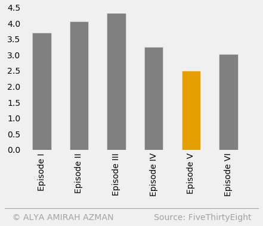

```python
# import packages for plotting
%matplotlib inline
import matplotlib.style as style
import matplotlib.pyplot as plt
style.use('fivethirtyeight')

# color-blind friendly colors
colors = [[0,0,0], [230/255,159/255,0], [86/255,180/255,233/255], [0,158/255,115/255],
          [213/255,94/255,0], [0,114/255,178/255]]

# make a bar chart of means of ranking columns
star_wars[star_wars.columns[9:15]].mean().plot.bar(color=([230/255,159/255,0] if x == min(star_wars[star_wars.columns[9:15]].mean()) else 'grey' for x in star_wars[star_wars.columns[9:15]].mean()))
plt.xticks([0, 1, 2, 3, 4, 5], ['Episode I', 'Episode II', 'Episode III', 'Episode IV', 'Episode V', 'Episode VI'])
plt.text(x = -1, y = -1.8,
    s = '_____________________________________________________________',
    color = 'grey', alpha = .7)

plt.text(x = -1, y = -2.2,
    s = '   © ALYA AMIRAH AZMAN               Source: FiveThirtyEight',
    fontsize = 14, color = 'grey', alpha = .7)
#plt.text(x = -2, y = 0.7, s = "Safety and respect is important for SATs",
#               fontsize = 18, weight = 'bold', alpha = .75)
#plt.text(x = -2, y = 0.6,
#               s = 'Positive correlation (< 0.25) can be seen from \nsafety and respect score (*saf) columns and SAT scores',
#              fontsize = 12, alpha = .85)
plt.grid(b=None)
```

```python
# check mean ranking of the movies
star_wars[star_wars.columns[9:15]].mean()
```

```
ranking_1    3.732934
ranking_2    4.087321
ranking_3    4.341317
ranking_4    3.272727
ranking_5    2.513158
ranking_6    3.047847
dtype: float64
```

```python
#  count the number of votes for Episode V: Empire Strikes Back
star_wars["ranking_5"].value_counts()
```

```
1.0    289
2.0    235
5.0    118
3.0    106
4.0     47
6.0     41
Name: ranking_5, dtype: int64
```

```python
# sum the number of votes for Episode V: Empire Strikes Back
star_wars["ranking_5"].value_counts().sum()
```

```
836
```

```python
# check missing values
star_wars["ranking_5"].isna().sum()
```

```
350
```

```python
# convert number of votes to percentages
((star_wars["ranking_5"].value_counts())/836)*100
```

```
1.0    34.569378
2.0    28.110048
5.0    14.114833
3.0    12.679426
4.0     5.622010
6.0     4.904306
Name: ranking_5, dtype: float64
```

```python
# convert number of votes to percentages
((star_wars["ranking_5"].value_counts())/1186)*100
```

```
1.0    24.367622
2.0    19.814503
5.0     9.949410
3.0     8.937605
4.0     3.962901
6.0     3.456998
Name: ranking_5, dtype: float64
```

```python
# invert the values, so that the most popular have the highest mean value
6 - star_wars[star_wars.columns[9:15]].mean()
```

```
ranking_1    2.267066
ranking_2    1.912679
ranking_3    1.658683
ranking_4    2.727273
ranking_5    3.486842
ranking_6    2.952153
dtype: float64
```

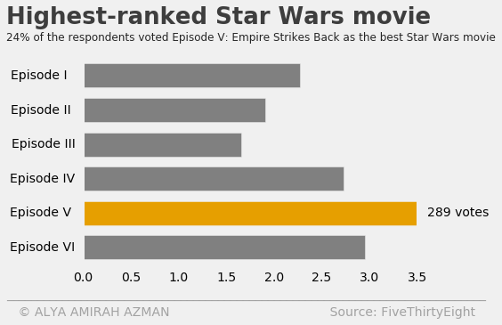

```python
style.use('fivethirtyeight')

# make a bar chart of mean ranking of each movie
(6 - star_wars[star_wars.columns[9:15]].mean()).plot.barh(color=([230/255,159/255,0] if x == min(star_wars[star_wars.columns[9:15]].mean()) else 'grey' for x in star_wars[star_wars.columns[9:15]].mean()), width= 0.7)
plt.yticks([0, 1, 2, 3, 4, 5], ['Episode I   ', 'Episode II  ', 'Episode III ', 'Episode IV ', 'Episode V  ', 'Episode VI '])
plt.gca().invert_yaxis()
plt.grid(b=None)
plt.text(x = -0.8, y = 6.5,
    s = '_____________________________________________________________________________',
    color = 'grey', alpha = .7)

plt.text(x = -0.8, y = 7,
    s = '   © ALYA AMIRAH AZMAN                                        Source: FiveThirtyEight',
    fontsize = 14, color = 'grey', alpha = .7)
plt.text(x = -0.8, y = -1.5, s = "Highest-ranked Star Wars movie",
               fontsize = 26, weight = 'bold', alpha = .75)
plt.text(x = -0.8, y = -1.0,
               s = '24% of the respondents voted Episode V: Empire Strikes Back as the best Star Wars movie',
              fontsize = 12, alpha = .85)
plt.text(x=3.6, y=4.1, s="289 votes")
```

# Finding the Most Viewed Movie

```python
# check number of views of each movie
star_wars[star_wars.columns[3:9]].sum()
```

```
seen_1    673
seen_2    571
seen_3    550
seen_4    607
seen_5    758
seen_6    738
dtype: int64
```

```python
# check of number of rows
star_wars.shape[0]
```

```
1186
```

```python
# count the number of votes for Episode V: Empire Strikes Back
star_wars["seen_5"].value_counts()
```

```
True     758
False    428
Name: seen_5, dtype: int64
```

```python
# convert values to percentages
(star_wars[star_wars.columns[3:9]].sum()/1186)*100
```

```
seen_1    56.745363
seen_2    48.145025
seen_3    46.374368
seen_4    51.180438
seen_5    63.912310
seen_6    62.225970
dtype: float64
```

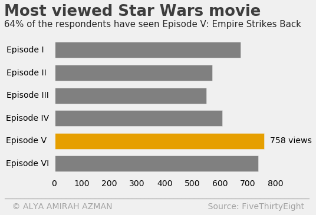

```python
style.use('fivethirtyeight')

# make a bar chart of the number of views of each movie
star_wars[star_wars.columns[3:9]].sum().plot.barh(color=([230/255,159/255,0] if x == max(star_wars[star_wars.columns[3:9]].sum()) else 'grey' for x in star_wars[star_wars.columns[3:9]].sum()), width= 0.7)
plt.yticks([0, 1, 2, 3, 4, 5], ['Episode I   ', 'Episode II  ', 'Episode III ', 'Episode IV ', 'Episode V  ', 'Episode VI '])
plt.gca().invert_yaxis()
plt.text(x = -180, y = 6.5,
    s = '__________________________________________________________________________',
    color = 'grey', alpha = .7)

plt.text(x = -180, y = 7,
    s = '   © ALYA AMIRAH AZMAN                                    Source: FiveThirtyEight',
    fontsize = 14, color = 'grey', alpha = .7)
plt.text(x = -180, y = -1.5, s = "Most viewed Star Wars movie",
               fontsize = 26, weight = 'bold', alpha = .75)
plt.text(x = -180, y = -1,
               s = '64% of the respondents have seen Episode V: Empire Strikes Back',
              fontsize = 15, alpha = .85)
plt.grid(b=None)
plt.text(x=780, y=4.1, s="758 views")
```

We plot the number of views of every Star Wars movie and found that Episode V: Empire Strikes Back is the most viewed viewed Star Wars movie. We calculated the percentage of respondents who have seen Episode V and we found that 64% of the respondents have seen the movie.

# Exploring the Data by Binary Segments

```python
# count the number of Star Wars fan
star_wars["Do you consider yourself to be a fan of the Star Wars film franchise?"].value_counts()
```

```
True     552
False    284
Name: Do you consider yourself to be a fan of the Star Wars film franchise?, dtype: int64
```

```python
# check missing values
star_wars["Do you consider yourself to be a fan of the Star Wars film franchise?"].isna().sum()
```

```
350
```

```python
# count the number of Star Trek fans
star_wars["Do you consider yourself to be a fan of the Star Trek franchise?"].value_counts()
```

```
No     641
Yes    427
Name: Do you consider yourself to be a fan of the Star Trek franchise?, dtype: int64
```

```python
# check missing values
star_wars["Do you consider yourself to be a fan of the Star Trek franchise?"].isna().sum()
```

```
118
```

```python
# count the number of fans of both Star Wars and Star Trek
grouped = star_wars.groupby(["Do you consider yourself to be a fan of the Star Wars film franchise?", "Do you consider yourself to be a fan of the Star Trek franchise?"])

grouped.size()
```

```
Do you consider yourself to be a fan of the Star Wars film franchise?  Do you consider yourself to be a fan of the Star Trek franchise?
False                                                                  No                                                                  238
                                                                       Yes                                                                  45
True                                                                   No                                                                  175
                                                                       Yes                                                                 370
dtype: int64
```

There are 552 Star Wars fans out of 1186 respondents and only 370 out of 552 Star Wars fans are fans of Star Trek.

```python
# split data into 2 groups - fans and non-fans
fans = star_wars[star_wars["Do you consider yourself to be a fan of the Star Wars film franchise?"] == True]
non_fans = star_wars[star_wars["Do you consider yourself to be a fan of the Star Wars film franchise?"] != True]
```

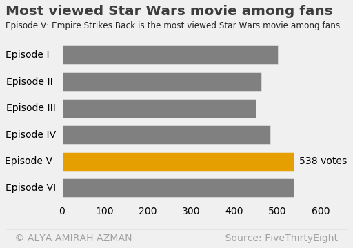

```python
style.use('fivethirtyeight')

# make a bar chart of the number of views of each movieamong fans
fans[fans.columns[3:9]].sum().plot.barh(color=([230/255,159/255,0] if x == max(fans[fans.columns[3:9]].sum()) else 'grey' for x in fans[fans.columns[3:9]].sum()), width= 0.7)
plt.yticks([0, 1, 2, 3, 4, 5], ['Episode I   ', 'Episode II  ', 'Episode III ', 'Episode IV ', 'Episode V  ', 'Episode VI '])
#plt.legend(reversed)
plt.gca().invert_yaxis()
plt.text(x = -130, y = 6.5,
    s = '_______________________________________________________________________',
    color = 'grey', alpha = .7)

plt.text(x = -130, y = 7,
    s = '   © ALYA AMIRAH AZMAN                              Source: FiveThirtyEight',
    fontsize = 14, color = 'grey', alpha = .7)
plt.text(x = -130, y = -1.5, s = "Most viewed Star Wars movie among fans",
               fontsize = 20, weight = 'bold', alpha = .75)
plt.text(x = -130, y = -1,
               s = 'Episode V: Empire Strikes Back is the most viewed Star Wars movie among fans',
              fontsize = 12, alpha = .85)
plt.grid(b=None)
plt.text(x=550, y=4.1, s="538 votes")
```

```python
# check number of views of each movie among fans
fans[fans.columns[3:9]].sum()
```

```
seen_1    500
seen_2    463
seen_3    450
seen_4    483
seen_5    538
seen_6    537
dtype: int64
```

```python
# check missing values
fans["seen_5"].isna().sum()
```

```
0
```

```python
# count the number of fans who have seen Empire Strikes Back
fans["seen_5"].value_counts()
```

```
True     538
False     14
Name: seen_5, dtype: int64
```

```python
# see data of fans who haven't seen Empire Strikes Back
fans[fans["seen_5"] == False]
```

|  | RespondentID | Have you seen any of the 6 films in the Star Wars franchise? | Do you consider yourself to be a fan of the Star Wars film franchise? | seen_1 | seen_2 | seen_3 | seen_4 | seen_5 | seen_6 | ranking_1 | ... | Unnamed: 28 | Which character shot first? | Are you familiar with the Expanded Universe? | Do you consider yourself to be a fan of the Expanded Universe?æ | Do you consider yourself to be a fan of the Star Trek franchise? | Gender | Age | Household Income | Education | Location (Census Region) |
| --- | --- | --- | --- | --- | --- | --- | --- | --- | --- | --- | --- | --- | --- | --- | --- | --- | --- | --- | --- | --- | --- |
| 17 | 3.292581e+09 | True | True | False | False | False | True | False | False | 4.0 | ... | Very unfavorably | Han | Yes | Yes | No | Male | 18-29 | $50,000 - $99,999 | Bachelor degree | New England |
| 18 | 3.292573e+09 | True | True | True | True | True | False | False | True | 1.0 | ... | Very favorably | Greedo | No | NaN | No | Male | 18-29 | NaN | Some college or Associate degree | Middle Atlantic |
| 62 | 3.292125e+09 | True | True | False | False | False | True | False | False | 1.0 | ... | NaN | Greedo | No | NaN | Yes | Male | 30-44 | $100,000 - $149,999 | Graduate degree | Pacific |
| 218 | 3.290971e+09 | True | True | True | True | False | False | False | False | 2.0 | ... | Very favorably | Greedo | No | NaN | No | Female | 30-44 | $50,000 - $99,999 | Some college or Associate degree | Pacific |
| 259 | 3.290884e+09 | True | True | True | True | True | True | False | True | 3.0 | ... | Very favorably | Greedo | Yes | No | Yes | Male | 45-60 | NaN | Bachelor degree | Pacific |
| 433 | 3.290600e+09 | True | True | False | False | False | False | False | True | 4.0 | ... | Very favorably | Greedo | No | NaN | Yes | Female | 30-44 | $25,000 - $49,999 | Graduate degree | West South Central |
| 464 | 3.290516e+09 | True | True | True | True | True | False | False | False | 1.0 | ... | Very favorably | I don't understand this question | No | NaN | Yes | Female | 45-60 | NaN | Graduate degree | Pacific |
| 469 | 3.290500e+09 | True | True | True | True | True | False | False | False | 1.0 | ... | Somewhat favorably | Han | No | NaN | Yes | Male | 45-60 | $100,000 - $149,999 | Some college or Associate degree | South Atlantic |
| 473 | 3.290492e+09 | True | True | True | True | True | False | False | False | 1.0 | ... | Somewhat favorably | Han | No | NaN | Yes | NaN | NaN | NaN | NaN | NaN |
| 599 | 3.290128e+09 | True | True | True | True | False | False | False | False | 1.0 | ... | Very favorably | I don't understand this question | No | NaN | Yes | Female | > 60 | $50,000 - $99,999 | Graduate degree | West South Central |
| 755 | 3.289800e+09 | True | True | True | False | False | False | False | False | 1.0 | ... | Very favorably | Greedo | No | NaN | Yes | Female | 30-44 | $150,000+ | Graduate degree | Pacific |
| 909 | 3.289394e+09 | True | True | False | True | False | False | False | False | 4.0 | ... | Neither favorably nor unfavorably (neutral) | I don't understand this question | Yes | Yes | No | Female | 18-29 | $25,000 - $49,999 | Bachelor degree | West North Central |
| 984 | 3.288698e+09 | True | True | True | False | False | False | False | False | 1.0 | ... | Very favorably | Han | No | NaN | Yes | Female | > 60 | $25,000 - $49,999 | Graduate degree | Pacific |
| 1113 | 3.288506e+09 | True | True | True | True | True | True | False | True | 5.0 | ... | Very favorably | Greedo | No | NaN | Yes | Male | 45-60 | $150,000+ | Graduate degree | Middle Atlantic |

14 rows × 38 columns